# 404_R_Project

Alex Li

2023-04-25

# Libraries

```r
library(tidyverse)
```

```r
library(corrplot)
library(ggplot2)
library(lubridate)
library(gridExtra)
library(caTools)
library(readxl)
```

# Data

```r
traindata <- read_csv("D:/School Stuff/Ryerson/Winter 2023/MTH404/R_Project/train.csv")
testdata <- read_csv("D:/School Stuff/Ryerson/Winter 2023/MTH404/R_Project/test.csv")
head(traindata,5)
```

```
## # A tibble: 5 × 81
##      Id MSSubClass MSZoning LotFrontage LotArea Street Alley LotShape
##   <dbl>      <dbl> <chr>          <dbl>   <dbl> <chr>  <chr> <chr>
## 1     1         60 RL                65    8450 Pave   <NA>  Reg
## 2     2         20 RL                80    9600 Pave   <NA>  Reg
## 3     3         60 RL                68   11250 Pave   <NA>  IR1
## 4     4         70 RL                60    9550 Pave   <NA>  IR1
## 5     5         60 RL                84   14260 Pave   <NA>  IR1
## # ℹ 73 more variables: LandContour <chr>, Utilities <chr>, LotConfig <chr>,
## #   LandSlope <chr>, Neighborhood <chr>, Condition1 <chr>, Condition2 <chr>,
## #   BldgType <chr>, HouseStyle <chr>, OverallQual <dbl>, OverallCond <dbl>,
## #   YearBuilt <dbl>, YearRemodAdd <dbl>, RoofStyle <chr>, RoofMatl <chr>,
## #   Exterior1st <chr>, Exterior2nd <chr>, MasVnrType <chr>, MasVnrArea <dbl>,
## #   ExterQual <chr>, ExterCond <chr>, Foundation <chr>, BsmtQual <chr>,
## #   BsmtCond <chr>, BsmtExposure <chr>, BsmtFinType1 <chr>, BsmtFinSF1 <dbl>, …
```

```r
head(testdata,5)
```

```
## # A tibble: 5 × 80
##      Id MSSubClass MSZoning LotFrontage LotArea Street Alley LotShape
##   <dbl>      <dbl> <chr>          <dbl>   <dbl> <chr>  <chr> <chr>
## 1  1461         20 RH                80   11622 Pave   <NA>  Reg
## 2  1462         20 RL                81   14267 Pave   <NA>  IR1
## 3  1463         60 RL                74   13830 Pave   <NA>  IR1
## 4  1464         60 RL                78    9978 Pave   <NA>  IR1
## 5  1465        120 RL                43    5005 Pave   <NA>  IR1
## # ℹ 72 more variables: LandContour <chr>, Utilities <chr>, LotConfig <chr>,
## #   LandSlope <chr>, Neighborhood <chr>, Condition1 <chr>, Condition2 <chr>,
## #   BldgType <chr>, HouseStyle <chr>, OverallQual <dbl>, OverallCond <dbl>,
## #   YearBuilt <dbl>, YearRemodAdd <dbl>, RoofStyle <chr>, RoofMatl <chr>,
## #   Exterior1st <chr>, Exterior2nd <chr>, MasVnrType <chr>, MasVnrArea <dbl>,
## #   ExterQual <chr>, ExterCond <chr>, Foundation <chr>, BsmtQual <chr>,
## #   BsmtCond <chr>, BsmtExposure <chr>, BsmtFinType1 <chr>, BsmtFinSF1 <dbl>, …
```

```r
str(traindata)
```

```
## spc_tbl_ [1,460 × 81] (S3: spec_tbl_df/tbl_df/tbl/data.frame)
##  $ Id           : num [1:1460] 1 2 3 4 5 6 7 8 9 10 ...
##  $ MSSubClass   : num [1:1460] 60 20 60 70 60 50 20 60 50 190 ...
##  $ MSZoning     : chr [1:1460] "RL" "RL" "RL" "RL" ...
##  $ LotFrontage  : num [1:1460] 65 80 68 60 84 85 75 NA 51 50 ...
##  $ LotArea      : num [1:1460] 8450 9600 11250 9550 14260 ...
##  $ Street       : chr [1:1460] "Pave" "Pave" "Pave" "Pave" ...
##  $ Alley        : chr [1:1460] NA NA NA NA ...
##  $ LotShape     : chr [1:1460] "Reg" "Reg" "IR1" "IR1" ...
##  $ LandContour  : chr [1:1460] "Lvl" "Lvl" "Lvl" "Lvl" ...
##  $ Utilities    : chr [1:1460] "AllPub" "AllPub" "AllPub" "AllPub" ...
##  $ LotConfig    : chr [1:1460] "Inside" "FR2" "Inside" "Corner" ...
##  $ LandSlope    : chr [1:1460] "Gtl" "Gtl" "Gtl" "Gtl" ...
##  $ Neighborhood : chr [1:1460] "CollgCr" "Veenker" "CollgCr" "Crawfor" ...
##  $ Condition1   : chr [1:1460] "Norm" "Feedr" "Norm" "Norm" ...
##  $ Condition2   : chr [1:1460] "Norm" "Norm" "Norm" "Norm" ...
##  $ BldgType     : chr [1:1460] "1Fam" "1Fam" "1Fam" "1Fam" ...
##  $ HouseStyle   : chr [1:1460] "2Story" "1Story" "2Story" "2Story" ...
##  $ OverallQual  : num [1:1460] 7 6 7 7 8 5 8 7 7 5 ...
##  $ OverallCond  : num [1:1460] 5 8 5 5 5 5 5 6 5 6 ...
##  $ YearBuilt    : num [1:1460] 2003 1976 2001 1915 2000 ...
##  $ YearRemodAdd : num [1:1460] 2003 1976 2002 1970 2000 ...
##  $ RoofStyle    : chr [1:1460] "Gable" "Gable" "Gable" "Gable" ...
##  $ RoofMatl     : chr [1:1460] "CompShg" "CompShg" "CompShg" "CompShg" ...
##  $ Exterior1st  : chr [1:1460] "VinylSd" "MetalSd" "VinylSd" "Wd Sdng" ...
##  $ Exterior2nd  : chr [1:1460] "VinylSd" "MetalSd" "VinylSd" "Wd Shng" ...
##  $ MasVnrType   : chr [1:1460] "BrkFace" "None" "BrkFace" "None" ...
##  $ MasVnrArea   : num [1:1460] 196 0 162 0 350 0 186 240 0 0 ...
##  $ ExterQual    : chr [1:1460] "Gd" "TA" "Gd" "TA" ...
##  $ ExterCond    : chr [1:1460] "TA" "TA" "TA" "TA" ...
##  $ Foundation   : chr [1:1460] "PConc" "CBlock" "PConc" "BrkTil" ...
##  $ BsmtQual     : chr [1:1460] "Gd" "Gd" "Gd" "TA" ...
##  $ BsmtCond     : chr [1:1460] "TA" "TA" "TA" "Gd" ...
##  $ BsmtExposure : chr [1:1460] "No" "Gd" "Mn" "No" ...
##  $ BsmtFinType1 : chr [1:1460] "GLQ" "ALQ" "GLQ" "ALQ" ...
##  $ BsmtFinSF1   : num [1:1460] 706 978 486 216 655 ...
##  $ BsmtFinType2 : chr [1:1460] "Unf" "Unf" "Unf" "Unf" ...
##  $ BsmtFinSF2   : num [1:1460] 0 0 0 0 0 0 0 32 0 0 ...
##  $ BsmtUnfSF    : num [1:1460] 150 284 434 540 490 64 317 216 952 140 ...
##  $ TotalBsmtSF  : num [1:1460] 856 1262 920 756 1145 ...
```

[output cut: 112 more lines]

```
##   ..   EnclosedPorch = col_double(),
##   ..   `3SsnPorch` = col_double(),
##   ..   ScreenPorch = col_double(),
##   ..   PoolArea = col_double(),
##   ..   PoolQC = col_character(),
##   ..   Fence = col_character(),
##   ..   MiscFeature = col_character(),
##   ..   MiscVal = col_double(),
##   ..   MoSold = col_double(),
##   ..   YrSold = col_double(),
##   ..   SaleType = col_character(),
##   ..   SaleCondition = col_character(),
##   ..   SalePrice = col_double()
##   .. )
##  - attr(*, "problems")=<externalptr>
```

```r
str(testdata)
```

```
## spc_tbl_ [1,459 × 80] (S3: spec_tbl_df/tbl_df/tbl/data.frame)
##  $ Id           : num [1:1459] 1461 1462 1463 1464 1465 ...
##  $ MSSubClass   : num [1:1459] 20 20 60 60 120 60 20 60 20 20 ...
##  $ MSZoning     : chr [1:1459] "RH" "RL" "RL" "RL" ...
##  $ LotFrontage  : num [1:1459] 80 81 74 78 43 75 NA 63 85 70 ...
##  $ LotArea      : num [1:1459] 11622 14267 13830 9978 5005 ...
##  $ Street       : chr [1:1459] "Pave" "Pave" "Pave" "Pave" ...
##  $ Alley        : chr [1:1459] NA NA NA NA ...
##  $ LotShape     : chr [1:1459] "Reg" "IR1" "IR1" "IR1" ...
##  $ LandContour  : chr [1:1459] "Lvl" "Lvl" "Lvl" "Lvl" ...
##  $ Utilities    : chr [1:1459] "AllPub" "AllPub" "AllPub" "AllPub" ...
##  $ LotConfig    : chr [1:1459] "Inside" "Corner" "Inside" "Inside" ...
##  $ LandSlope    : chr [1:1459] "Gtl" "Gtl" "Gtl" "Gtl" ...
##  $ Neighborhood : chr [1:1459] "NAmes" "NAmes" "Gilbert" "Gilbert" ...
##  $ Condition1   : chr [1:1459] "Feedr" "Norm" "Norm" "Norm" ...
##  $ Condition2   : chr [1:1459] "Norm" "Norm" "Norm" "Norm" ...
##  $ BldgType     : chr [1:1459] "1Fam" "1Fam" "1Fam" "1Fam" ...
##  $ HouseStyle   : chr [1:1459] "1Story" "1Story" "2Story" "2Story" ...
##  $ OverallQual  : num [1:1459] 5 6 5 6 8 6 6 6 7 4 ...
##  $ OverallCond  : num [1:1459] 6 6 5 6 5 5 7 5 5 5 ...
##  $ YearBuilt    : num [1:1459] 1961 1958 1997 1998 1992 ...
##  $ YearRemodAdd : num [1:1459] 1961 1958 1998 1998 1992 ...
##  $ RoofStyle    : chr [1:1459] "Gable" "Hip" "Gable" "Gable" ...
##  $ RoofMatl     : chr [1:1459] "CompShg" "CompShg" "CompShg" "CompShg" ...
##  $ Exterior1st  : chr [1:1459] "VinylSd" "Wd Sdng" "VinylSd" "VinylSd" ...
##  $ Exterior2nd  : chr [1:1459] "VinylSd" "Wd Sdng" "VinylSd" "VinylSd" ...
##  $ MasVnrType   : chr [1:1459] "None" "BrkFace" "None" "BrkFace" ...
##  $ MasVnrArea   : num [1:1459] 0 108 0 20 0 0 0 0 0 0 ...
##  $ ExterQual    : chr [1:1459] "TA" "TA" "TA" "TA" ...
##  $ ExterCond    : chr [1:1459] "TA" "TA" "TA" "TA" ...
##  $ Foundation   : chr [1:1459] "CBlock" "CBlock" "PConc" "PConc" ...
##  $ BsmtQual     : chr [1:1459] "TA" "TA" "Gd" "TA" ...
##  $ BsmtCond     : chr [1:1459] "TA" "TA" "TA" "TA" ...
##  $ BsmtExposure : chr [1:1459] "No" "No" "No" "No" ...
##  $ BsmtFinType1 : chr [1:1459] "Rec" "ALQ" "GLQ" "GLQ" ...
##  $ BsmtFinSF1   : num [1:1459] 468 923 791 602 263 0 935 0 637 804 ...
##  $ BsmtFinType2 : chr [1:1459] "LwQ" "Unf" "Unf" "Unf" ...
##  $ BsmtFinSF2   : num [1:1459] 144 0 0 0 0 0 0 0 0 78 ...
##  $ BsmtUnfSF    : num [1:1459] 270 406 137 324 1017 ...
##  $ TotalBsmtSF  : num [1:1459] 882 1329 928 926 1280 ...
```

[output cut: 110 more lines]

```
##   ..   OpenPorchSF = col_double(),
##   ..   EnclosedPorch = col_double(),
##   ..   `3SsnPorch` = col_double(),
##   ..   ScreenPorch = col_double(),
##   ..   PoolArea = col_double(),
##   ..   PoolQC = col_character(),
##   ..   Fence = col_character(),
##   ..   MiscFeature = col_character(),
##   ..   MiscVal = col_double(),
##   ..   MoSold = col_double(),
##   ..   YrSold = col_double(),
##   ..   SaleType = col_character(),
##   ..   SaleCondition = col_character()
##   .. )
##  - attr(*, "problems")=<externalptr>
```

# Tables Summary

```r
table(traindata$MSZoning)
```

```
##
## C (all)      FV      RH      RL      RM
##      10      65      16    1151     218
```

```r
table(traindata$Street)
```

```
##
## Grvl Pave
##    6 1454
```

```r
table(traindata$Alley)
```

```
##
## Grvl Pave
##   50   41
```

```r
table(traindata$LotShape)
```

```
##
## IR1 IR2 IR3 Reg
## 484  41  10 925
```

```r
table(traindata$LandContour)
```

```
##
##  Bnk  HLS  Low  Lvl
##   63   50   36 1311
```

```r
table(traindata$Utilities)
```

```
##
## AllPub NoSeWa
##   1459      1
```

```r
table(traindata$LotConfig)
```

```
##
##  Corner CulDSac     FR2     FR3  Inside
##     263      94      47       4    1052
```

```r
table(traindata$LandSlope)
```

```
##
##  Gtl  Mod  Sev
## 1382   65   13
```

```r
table(traindata$Neighborhood)
```

```
##
## Blmngtn Blueste  BrDale BrkSide ClearCr CollgCr Crawfor Edwards Gilbert  IDOTRR
##      17       2      16      58      28     150      51     100      79      37
## MeadowV Mitchel   NAmes NoRidge NPkVill NridgHt  NWAmes OldTown  Sawyer SawyerW
##      17      49     225      41       9      77      73     113      74      59
## Somerst StoneBr   SWISU  Timber Veenker
##      86      25      25      38      11
```

```r
table(traindata$Condition1)
```

```
##
## Artery  Feedr   Norm   PosA   PosN   RRAe   RRAn   RRNe   RRNn
##     48     81   1260      8     19     11     26      2      5
```

```r
table(traindata$Condition2)
```

```
##
## Artery  Feedr   Norm   PosA   PosN   RRAe   RRAn   RRNn
##      2      6   1445      1      2      1      1      2
```

```r
table(traindata$BldgType)
```

```
##
##   1Fam 2fmCon Duplex  Twnhs TwnhsE
##   1220     31     52     43    114
```

```r
table(traindata$HouseStyle)
```

```
##
## 1.5Fin 1.5Unf 1Story 2.5Fin 2.5Unf 2Story SFoyer   SLvl
##    154     14    726      8     11    445     37     65
```

```r
table(traindata$RoofStyle)
```

```
##
##    Flat   Gable Gambrel     Hip Mansard    Shed
##      13    1141      11     286       7       2
```

```r
table(traindata$RoofMatl)
```

```
##
## ClyTile CompShg Membran   Metal    Roll Tar&Grv WdShake WdShngl
##       1    1434       1       1       1      11       5       6
```

```r
table(traindata$Exterior1st)
```

```
##
## AsbShng AsphShn BrkComm BrkFace  CBlock CemntBd HdBoard ImStucc MetalSd Plywood
##      20       1       2      50       1      61     222       1     220     108
##   Stone  Stucco VinylSd Wd Sdng WdShing
##       2      25     515     206      26
```

```r
table(traindata$Exterior2nd)
```

```
##
## AsbShng AsphShn Brk Cmn BrkFace  CBlock CmentBd HdBoard ImStucc MetalSd   Other
##      20       3       7      25       1      60     207      10     214       1
## Plywood   Stone  Stucco VinylSd Wd Sdng Wd Shng
##     142       5      26     504     197      38
```

```r
table(traindata$MasVnrType)
```

```
##
##  BrkCmn BrkFace    None   Stone
##      15     445     864     128
```

```r
table(traindata$ExterQual)
```

```
##
##  Ex  Fa  Gd  TA
##  52  14 488 906
```

```r
table(traindata$ExterCond)
```

```
##
##   Ex   Fa   Gd   Po   TA
##    3   28  146    1 1282
```

```r
table(traindata$Foundation)
```

```
##
## BrkTil CBlock  PConc   Slab  Stone   Wood
##    146    634    647     24      6      3
```

```r
table(traindata$BsmtQual)
```

```
##
##  Ex  Fa  Gd  TA
## 121  35 618 649
```

```r
table(traindata$BsmtCond)
```

```
##
##   Fa   Gd   Po   TA
##   45   65    2 1311
```

```r
table(traindata$BsmtExposure)
```

```
##
##  Av  Gd  Mn  No
## 221 134 114 953
```

```r
table(traindata$BsmtFinType1)
```

```
##
## ALQ BLQ GLQ LwQ Rec Unf
## 220 148 418  74 133 430
```

```r
table(traindata$BsmtFinType2)
```

```
##
##  ALQ  BLQ  GLQ  LwQ  Rec  Unf
##   19   33   14   46   54 1256
```

```r
table(traindata$Heating)
```

```
##
## Floor  GasA  GasW  Grav  OthW  Wall
##     1  1428    18     7     2     4
```

```r
table(traindata$HeatingQC)
```

```
##
##  Ex  Fa  Gd  Po  TA
## 741  49 241   1 428
```

```r
table(traindata$CentralAir)
```

```
##
##    N    Y
##   95 1365
```

```r
table(traindata$Electrical)
```

```
##
## FuseA FuseF FuseP   Mix SBrkr
##    94    27     3     1  1334
```

```r
table(traindata$KitchenQual)
```

```
##
##  Ex  Fa  Gd  TA
## 100  39 586 735
```

```r
table(traindata$Functional)
```

```
##
## Maj1 Maj2 Min1 Min2  Mod  Sev  Typ
##   14    5   31   34   15    1 1360
```

```r
table(traindata$FireplaceQu)
```

```
##
##  Ex  Fa  Gd  Po  TA
##  24  33 380  20 313
```

```r
table(traindata$GarageType)
```

```
##
##  2Types  Attchd Basment BuiltIn CarPort  Detchd
##       6     870      19      88       9     387
```

```r
table(traindata$GarageFinish)
```

```
##
## Fin RFn Unf
## 352 422 605
```

```r
table(traindata$GarageQual)
```

```
##
##   Ex   Fa   Gd   Po   TA
##    3   48   14    3 1311
```

```r
table(traindata$GarageCond)
```

```
##
##   Ex   Fa   Gd   Po   TA
##    2   35    9    7 1326
```

```r
table(traindata$PavedDrive)
```

```
##
##    N    P    Y
##   90   30 1340
```

```r
table(traindata$PoolQC)
```

```
##
## Ex Fa Gd
##  2  2  3
```

```r
table(traindata$Fence)
```

```
##
## GdPrv  GdWo MnPrv  MnWw
##    59    54   157    11
```

```r
table(traindata$MiscFeature)
```

```
##
## Gar2 Othr Shed TenC
##    2    2   49    1
```

```r
table(traindata$SaleType)
```

```
##
##   COD   Con ConLD ConLI ConLw   CWD   New   Oth    WD
##    43     2     9     5     5     4   122     3  1267
```

```r
table(traindata$SaleCondition)
```

```
##
## Abnorml AdjLand  Alloca  Family  Normal Partial
##     101       4      12      20    1198     125
```

# Removing Missing Values

```r
mydata2 <- traindata[c("Id", "LotFrontage", "LotArea","OverallQual","OverallCond", "YearBuilt", "YearRemodAdd", "MasVnrArea", "TotalBsmtSF", "GrLivArea", "TotRmsAbvGrd", "Fireplaces", "GarageYrBlt", "GarageArea", "EnclosedPorch", "PoolArea", "MiscVal", "YrSold", "SalePrice", "HouseStyle")]
summary(mydata2)
```

```
##        Id          LotFrontage        LotArea        OverallQual
##  Min.   :   1.0   Min.   : 21.00   Min.   :  1300   Min.   : 1.000
##  1st Qu.: 365.8   1st Qu.: 59.00   1st Qu.:  7554   1st Qu.: 5.000
##  Median : 730.5   Median : 69.00   Median :  9478   Median : 6.000
##  Mean   : 730.5   Mean   : 70.05   Mean   : 10517   Mean   : 6.099
##  3rd Qu.:1095.2   3rd Qu.: 80.00   3rd Qu.: 11602   3rd Qu.: 7.000
##  Max.   :1460.0   Max.   :313.00   Max.   :215245   Max.   :10.000
##                   NA's   :259
##   OverallCond      YearBuilt     YearRemodAdd    MasVnrArea
##  Min.   :1.000   Min.   :1872   Min.   :1950   Min.   :   0.0
##  1st Qu.:5.000   1st Qu.:1954   1st Qu.:1967   1st Qu.:   0.0
##  Median :5.000   Median :1973   Median :1994   Median :   0.0
##  Mean   :5.575   Mean   :1971   Mean   :1985   Mean   : 103.7
##  3rd Qu.:6.000   3rd Qu.:2000   3rd Qu.:2004   3rd Qu.: 166.0
##  Max.   :9.000   Max.   :2010   Max.   :2010   Max.   :1600.0
##                                                NA's   :8
##   TotalBsmtSF       GrLivArea     TotRmsAbvGrd      Fireplaces
##  Min.   :   0.0   Min.   : 334   Min.   : 2.000   Min.   :0.000
##  1st Qu.: 795.8   1st Qu.:1130   1st Qu.: 5.000   1st Qu.:0.000
##  Median : 991.5   Median :1464   Median : 6.000   Median :1.000
##  Mean   :1057.4   Mean   :1515   Mean   : 6.518   Mean   :0.613
##  3rd Qu.:1298.2   3rd Qu.:1777   3rd Qu.: 7.000   3rd Qu.:1.000
##  Max.   :6110.0   Max.   :5642   Max.   :14.000   Max.   :3.000
##
##   GarageYrBlt     GarageArea     EnclosedPorch       PoolArea
##  Min.   :1900   Min.   :   0.0   Min.   :  0.00   Min.   :  0.000
##  1st Qu.:1961   1st Qu.: 334.5   1st Qu.:  0.00   1st Qu.:  0.000
##  Median :1980   Median : 480.0   Median :  0.00   Median :  0.000
##  Mean   :1979   Mean   : 473.0   Mean   : 21.95   Mean   :  2.759
##  3rd Qu.:2002   3rd Qu.: 576.0   3rd Qu.:  0.00   3rd Qu.:  0.000
##  Max.   :2010   Max.   :1418.0   Max.   :552.00   Max.   :738.000
##  NA's   :81
##     MiscVal             YrSold       SalePrice       HouseStyle
##  Min.   :    0.00   Min.   :2006   Min.   : 34900   Length:1460
##  1st Qu.:    0.00   1st Qu.:2007   1st Qu.:129975   Class :character
##  Median :    0.00   Median :2008   Median :163000   Mode  :character
##  Mean   :   43.49   Mean   :2008   Mean   :180921
##  3rd Qu.:    0.00   3rd Qu.:2009   3rd Qu.:214000
##  Max.   :15500.00   Max.   :2010   Max.   :755000
##
```

```r
mydata2clean <- na.omit(mydata2)
summary(mydata2clean)
```

```
##        Id          LotFrontage        LotArea        OverallQual
##  Min.   :   1.0   Min.   : 21.00   Min.   :  1300   Min.   : 2.000
##  1st Qu.: 364.0   1st Qu.: 60.00   1st Qu.:  7590   1st Qu.: 5.000
##  Median : 725.0   Median : 70.00   Median :  9416   Median : 6.000
##  Mean   : 726.8   Mean   : 70.67   Mean   : 10123   Mean   : 6.212
##  3rd Qu.:1091.0   3rd Qu.: 80.00   3rd Qu.: 11361   3rd Qu.: 7.000
##  Max.   :1460.0   Max.   :313.00   Max.   :215245   Max.   :10.000
##   OverallCond      YearBuilt     YearRemodAdd    MasVnrArea      TotalBsmtSF
##  Min.   :2.000   Min.   :1880   Min.   :1950   Min.   :   0.0   Min.   :   0
##  1st Qu.:5.000   1st Qu.:1953   1st Qu.:1966   1st Qu.:   0.0   1st Qu.: 803
##  Median :5.000   Median :1974   Median :1995   Median :   0.0   Median :1008
##  Mean   :5.561   Mean   :1972   Mean   :1986   Mean   : 108.5   Mean   :1077
##  3rd Qu.:6.000   3rd Qu.:2003   3rd Qu.:2005   3rd Qu.: 170.0   3rd Qu.:1324
##  Max.   :9.000   Max.   :2010   Max.   :2010   Max.   :1600.0   Max.   :6110
##    GrLivArea     TotRmsAbvGrd      Fireplaces      GarageYrBlt     GarageArea
##  Min.   : 438   Min.   : 3.000   Min.   :0.0000   Min.   :1900   Min.   : 160
##  1st Qu.:1155   1st Qu.: 5.000   1st Qu.:0.0000   1st Qu.:1959   1st Qu.: 360
##  Median :1479   Median : 6.000   Median :1.0000   Median :1981   Median : 484
##  Mean   :1531   Mean   : 6.576   Mean   :0.6039   Mean   :1978   Mean   : 503
##  3rd Qu.:1776   3rd Qu.: 7.000   3rd Qu.:1.0000   3rd Qu.:2003   3rd Qu.: 600
##  Max.   :5642   Max.   :12.000   Max.   :3.0000   Max.   :2010   Max.   :1418
##  EnclosedPorch       PoolArea          MiscVal            YrSold
##  Min.   :  0.00   Min.   :  0.000   Min.   :   0.00   Min.   :2006
##  1st Qu.:  0.00   1st Qu.:  0.000   1st Qu.:   0.00   1st Qu.:2007
##  Median :  0.00   Median :  0.000   Median :   0.00   Median :2008
##  Mean   : 21.84   Mean   :  2.935   Mean   :  23.43   Mean   :2008
##  3rd Qu.:  0.00   3rd Qu.:  0.000   3rd Qu.:   0.00   3rd Qu.:2009
##  Max.   :552.00   Max.   :648.000   Max.   :2500.00   Max.   :2010
##    SalePrice       HouseStyle
##  Min.   : 35311   Length:1121
##  1st Qu.:131000   Class :character
##  Median :164900   Mode  :character
##  Mean   :185506
##  3rd Qu.:219500
##  Max.   :755000
```

```r
set.seed(123)
split <- sample.split(mydata2clean$Id, SplitRatio = 0.8)
train <- subset(mydata2clean, split == TRUE)
test <- subset(mydata2clean, split == FALSE)
```

# Exploratory Data Analysis on The Train Data

## Determining the Association Between Variables

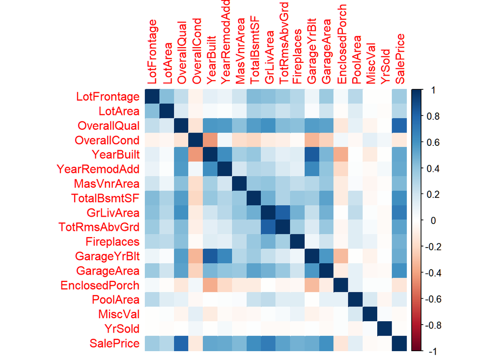

```r
cor_data=data.frame(train[,2:19])
correlation=cor(cor_data)
par(mfrow=c(1, 1))
corrplot(correlation,method="color")
```

SalePrice is strongly related with OverallQual, YearBuilt, YearRemodAdd, MasVnrArea, TotalBsmtSF, GrLivArea, TotRmsAbvGrd, Fireplaces, GarageYrBlt, GarageArea

### Scatterplots

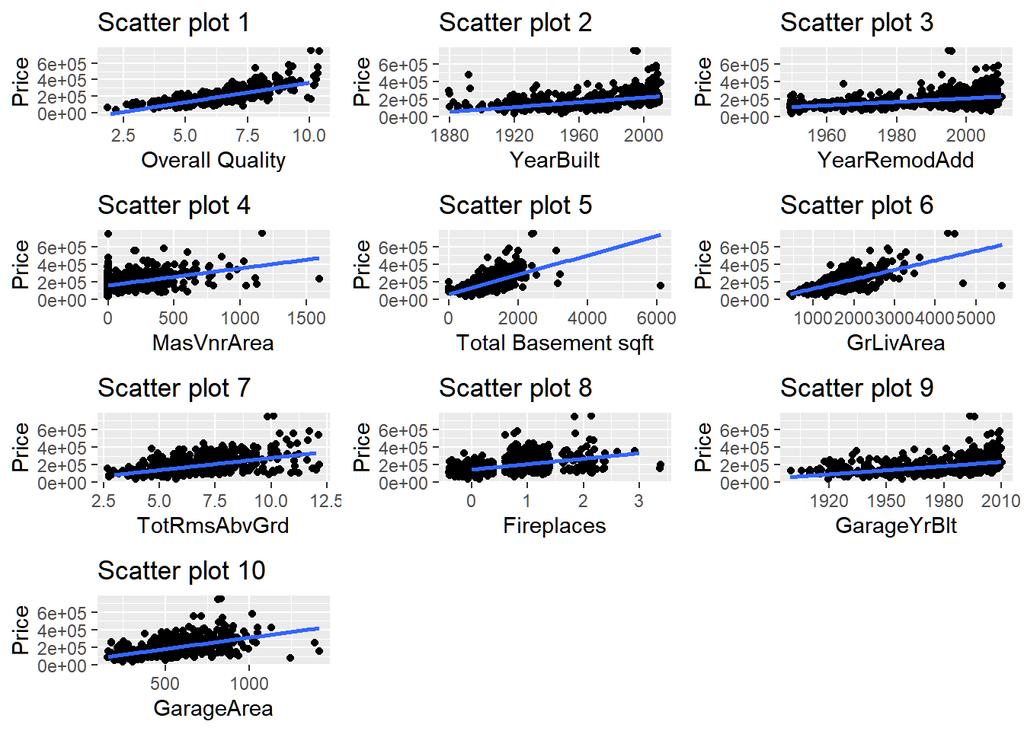

```r
p1=ggplot(data = train, aes(x = OverallQual, y = SalePrice)) +
  geom_jitter() +  geom_smooth(method = "lm", se = FALSE)+labs(title="Scatter plot 1", x="Overall Quality",y="Price")

p2=ggplot(data = train, aes(x = YearBuilt, y = SalePrice)) +
  geom_jitter() +  geom_smooth(method = "lm", se = FALSE)+labs(title="Scatter plot 2", x="YearBuilt",y="Price")

p3=ggplot(data = train, aes(x = YearRemodAdd, y = SalePrice)) +
  geom_jitter() +  geom_smooth(method = "lm", se = FALSE)+labs(title="Scatter plot 3", x="YearRemodAdd",y="Price")

p4=ggplot(data = train, aes(x = MasVnrArea, y = SalePrice)) +
  geom_jitter() +  geom_smooth(method = "lm", se = FALSE)+labs(title="Scatter plot 4", x="MasVnrArea",y="Price")

p5=ggplot(data = train, aes(x = TotalBsmtSF, y = SalePrice)) +
  geom_jitter() +  geom_smooth(method = "lm", se = FALSE)+labs(title="Scatter plot 5", x="Total Basement sqft",y="Price")

p6=ggplot(data = train, aes(x = GrLivArea, y = SalePrice)) +
  geom_jitter() +  geom_smooth(method = "lm", se = FALSE)+labs(title="Scatter plot 6", x="GrLivArea",y="Price")

p7=ggplot(data = train, aes(x = TotRmsAbvGrd, y = SalePrice)) +
  geom_jitter() +  geom_smooth(method = "lm", se = FALSE)+labs(title="Scatter plot 7", x="TotRmsAbvGrd",y="Price")

p8=ggplot(data = train, aes(x = Fireplaces, y = SalePrice)) +
  geom_jitter() +  geom_smooth(method = "lm", se = FALSE)+labs(title="Scatter plot 8", x="Fireplaces",y="Price")

p9=ggplot(data = train, aes(x = GarageYrBlt, y = SalePrice)) +
  geom_jitter() +  geom_smooth(method = "lm", se = FALSE)+labs(title="Scatter plot 9", x="GarageYrBlt",y="Price")

p10=ggplot(data = train, aes(x = GarageArea, y = SalePrice)) +
  geom_jitter() +  geom_smooth(method = "lm", se = FALSE)+labs(title="Scatter plot 10", x="GarageArea",y="Price")

grid.arrange(p1,p2,p3,p4,p5,p6,p7,p8,p9,p10, nrow=4)
```

There is positive linear relationship of sale price with overall quality, year built, year remodelled, masvnrarea, total basement sqft, ground living area, total rooms above ground, fireplaces, garage built year, and garage area

### Boxplots

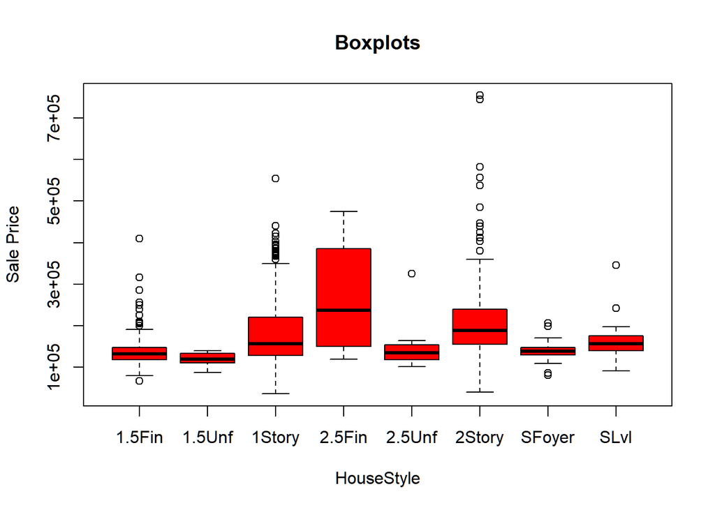

```r
boxplot(SalePrice~HouseStyle,data=train,main="Boxplots", xlab="HouseStyle",ylab="Sale Price", col="red")
```

## Modifying Our Train Data

```r
train$age=c(train$YrSold-train$YearBuilt)
```

## Outliers in the Dependent Variable

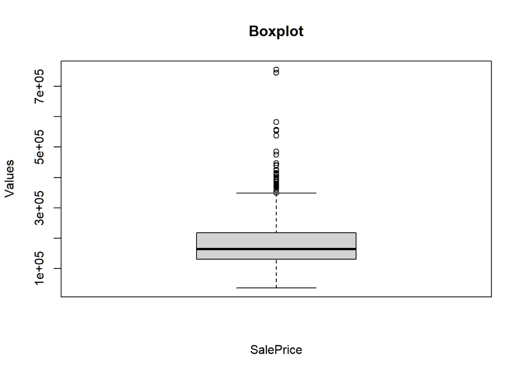

```r
boxplot(train$SalePrice, main="Boxplot", xlab="SalePrice", ylab="Values")
```

```r
outliers=boxplot(train$SalePrice,plot=FALSE)$out
outliers_data=train[which(train$SalePrice %in% outliers),]
length(outliers_data)
```

```
## [1] 21
```

```r
train_data1= train[-which(train$SalePrice %in% outliers),]
```

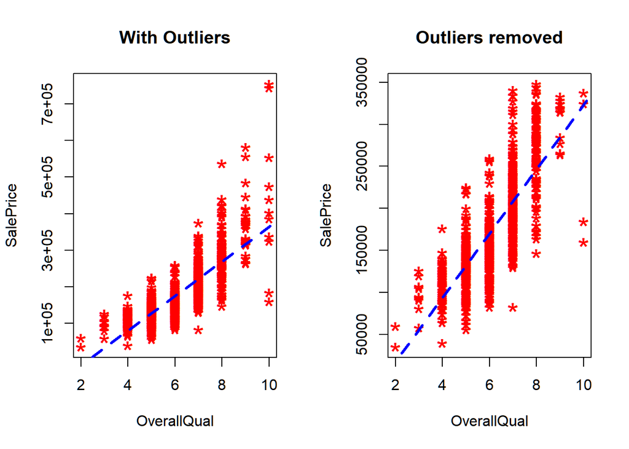

```r
par(mfrow=c(1, 2))
plot(train$OverallQual, train$SalePrice, main="With Outliers", xlab="OverallQual", ylab="SalePrice", pch="*", col="red", cex=2)
abline(lm(SalePrice ~ OverallQual, data=train), col="blue", lwd=3, lty=2)
plot(train_data1$OverallQual, train_data1$SalePrice, main="Outliers removed", xlab="OverallQual", ylab="SalePrice", pch="*", col="red", cex=2)
abline(lm(SalePrice ~OverallQual, data=train_data1), col="blue", lwd=3, lty=2)
```

# Modelling

## Modelling on the Entire Train Data

```r
model1=lm(data=train,SalePrice~OverallQual+YearBuilt+YearRemodAdd+MasVnrArea+TotalBsmtSF+GrLivArea+TotRmsAbvGrd+Fireplaces+GarageYrBlt+GarageArea+age)
summary(model1)
```

```
##
## Call:
## lm(formula = SalePrice ~ OverallQual + YearBuilt + YearRemodAdd +
##     MasVnrArea + TotalBsmtSF + GrLivArea + TotRmsAbvGrd + Fireplaces +
##     GarageYrBlt + GarageArea + age, data = train)
##
## Residuals:
##     Min      1Q  Median      3Q     Max
## -474640  -20547   -1729   16574  297396
##
## Coefficients:
##                Estimate Std. Error t value Pr(>|t|)
## (Intercept)  -4.307e+05  2.021e+06  -0.213   0.8313
## OverallQual   2.065e+04  1.672e+03  12.351  < 2e-16 ***
## YearBuilt    -1.148e+02  1.015e+03  -0.113   0.9099
## YearRemodAdd  3.908e+02  9.035e+01   4.325 1.70e-05 ***
## MasVnrArea    1.752e+01  8.356e+00   2.097   0.0363 *
## TotalBsmtSF   1.964e+01  4.018e+00   4.888 1.21e-06 ***
## GrLivArea     3.750e+01  5.475e+00   6.849 1.39e-11 ***
## TotRmsAbvGrd  1.517e+03  1.519e+03   0.999   0.3182
## Fireplaces    1.376e+04  2.564e+03   5.367 1.02e-07 ***
## GarageYrBlt  -8.894e+01  1.088e+02  -0.817   0.4140
## GarageArea    5.522e+01  1.028e+01   5.370 1.00e-07 ***
## age          -3.604e+02  1.007e+03  -0.358   0.7206
## ---
## Signif. codes:  0 '***' 0.001 '**' 0.01 '*' 0.05 '.' 0.1 ' ' 1
##
## Residual standard error: 40360 on 884 degrees of freedom
## Multiple R-squared:  0.759,  Adjusted R-squared:  0.756
## F-statistic: 253.1 on 11 and 884 DF,  p-value: < 2.2e-16
```

There is 75.9% variation in the R square which is explained by all independent variables in the model. With p>5% the in-significant variabels in the model are YearBuilt, TotRmsAbvGrd, GarageYrBlt, and age. Hence remove these in-signfiicant variables and re-run the regression model.

```r
model2=lm(data=train,SalePrice~OverallQual+YearRemodAdd+MasVnrArea+TotalBsmtSF+GrLivArea+Fireplaces+GarageArea)
summary(model2)
```

```
##
## Call:
## lm(formula = SalePrice ~ OverallQual + YearRemodAdd + MasVnrArea +
##     TotalBsmtSF + GrLivArea + Fireplaces + GarageArea, data = train)
##
## Residuals:
##     Min      1Q  Median      3Q     Max
## -481130  -20349   -1778   17363  297019
##
## Coefficients:
##                Estimate Std. Error t value Pr(>|t|)
## (Intercept)  -1.024e+06  1.539e+05  -6.653 5.02e-11 ***
## OverallQual   2.212e+04  1.597e+03  13.852  < 2e-16 ***
## YearRemodAdd  4.787e+02  7.975e+01   6.003 2.82e-09 ***
## MasVnrArea    2.246e+01  8.251e+00   2.723   0.0066 **
## TotalBsmtSF   2.055e+01  3.948e+00   5.206 2.40e-07 ***
## GrLivArea     3.827e+01  3.494e+00  10.952  < 2e-16 ***
## Fireplaces    1.375e+04  2.546e+03   5.400 8.55e-08 ***
## GarageArea    5.755e+01  9.337e+00   6.164 1.08e-09 ***
## ---
## Signif. codes:  0 '***' 0.001 '**' 0.01 '*' 0.05 '.' 0.1 ' ' 1
##
## Residual standard error: 40530 on 888 degrees of freedom
## Multiple R-squared:  0.7559, Adjusted R-squared:  0.7539
## F-statistic: 392.7 on 7 and 888 DF,  p-value: < 2.2e-16
```

There is 75.59% variation in the R square which is explained by all independent variables in the model. With p<5%, all independent variables in the model are significant.

## Detect the Influential Points of the Data

```r
cooksd <- cooks.distance(model2)
mean(cooksd)
```

```
## [1] 0.007838143
```

[figure not shown]

```r
par(mfrow=c(1, 1))
plot(cooksd, main="Influential Obs by Cooks distance",xlim=c(0,1000),ylim=c(0,0.1))
axis(1, at=seq(0, 1000, 200))
axis(2, at=seq(0, 0.1, 0.0001))
abline(h = 4*mean(cooksd, na.rm=T), col="green")
text(x=1:length(cooksd)+1,y=cooksd,labels=ifelse(cooksd>4*mean(cooksd,na.rm=T),names(cooksd),""), col="red")
```

```r
influential <- as.numeric(names(cooksd)[(cooksd > 4*mean(cooksd, na.rm=T))])  # influential row numbers
head(train[influential, ])
```

```
## # A tibble: 6 × 21
##      Id LotFrontage LotArea OverallQual OverallCond YearBuilt YearRemodAdd
##   <dbl>       <dbl>   <dbl>       <dbl>       <dbl>     <dbl>        <dbl>
## 1   441         105   15431          10           5      2008         2008
## 2   524         130   40094          10           5      2007         2008
## 3   692         104   21535          10           6      1994         1995
## 4   770          47   53504           8           5      2003         2003
## 5   804         107   13891           9           5      2008         2009
## 6  1047          85   16056           9           5      2005         2006
## # ℹ 14 more variables: MasVnrArea <dbl>, TotalBsmtSF <dbl>, GrLivArea <dbl>,
## #   TotRmsAbvGrd <dbl>, Fireplaces <dbl>, GarageYrBlt <dbl>, GarageArea <dbl>,
## #   EnclosedPorch <dbl>, PoolArea <dbl>, MiscVal <dbl>, YrSold <dbl>,
## #   SalePrice <dbl>, HouseStyle <chr>, age <dbl>
```

```r
influential_data=train[influential, ]
influencial_outliers=inner_join(outliers_data,influential_data)
```

[output not shown]

```r
train_data2=rbind(train_data1,influencial_outliers)
```

## Modelling with Influential Outliers

```r
model3=lm(data=train_data2,SalePrice~OverallQual+YearRemodAdd+MasVnrArea+TotalBsmtSF+GrLivArea+Fireplaces+GarageArea)
summary(model3)
```

```
##
## Call:
## lm(formula = SalePrice ~ OverallQual + YearRemodAdd + MasVnrArea +
##     TotalBsmtSF + GrLivArea + Fireplaces + GarageArea, data = train_data2)
##
## Residuals:
##     Min      1Q  Median      3Q     Max
## -438291  -17079    -275   16779  317634
##
## Coefficients:
##                Estimate Std. Error t value Pr(>|t|)
## (Intercept)  -1.077e+06  1.441e+05  -7.476 1.89e-13 ***
## OverallQual   1.969e+04  1.522e+03  12.932  < 2e-16 ***
## YearRemodAdd  5.167e+02  7.474e+01   6.913 9.23e-12 ***
## MasVnrArea    1.774e+01  8.171e+00   2.171   0.0302 *
## TotalBsmtSF   1.744e+01  3.754e+00   4.644 3.95e-06 ***
## GrLivArea     3.822e+01  3.369e+00  11.345  < 2e-16 ***
## Fireplaces    1.245e+04  2.417e+03   5.153 3.19e-07 ***
## GarageArea    4.765e+01  8.931e+00   5.335 1.22e-07 ***
## ---
## Signif. codes:  0 '***' 0.001 '**' 0.01 '*' 0.05 '.' 0.1 ' ' 1
##
## Residual standard error: 37770 on 858 degrees of freedom
## Multiple R-squared:  0.7285, Adjusted R-squared:  0.7263
## F-statistic: 328.9 on 7 and 858 DF,  p-value: < 2.2e-16
```

## Accuracy of the Model on the Train Data

```r
pred=model3$fitted.values
tally_table=data.frame(actual=train_data2$SalePrice, predicted=pred)
mape=mean(abs(tally_table$actual-tally_table$predicted)/tally_table$actual)
accuracy=1-mape
accuracy
```

```
## [1] 0.8617627
```

The Model can predict price with an accuracy of 86%.

# Prediction on the Test Data

```r
test_data_1 <- test[c("OverallQual", "YearRemodAdd", "MasVnrArea","TotalBsmtSF","GrLivArea", "Fireplaces", "GarageArea", "SalePrice")]
pred_test=predict(newdata=test_data_1,model3)
```

## Accuracy of the Model on the Test Data

```r
tally_table_1=data.frame(actual=test$SalePrice, predicted=pred_test)
mape_test=mean(abs(tally_table_1$actual-tally_table_1$predicted)/tally_table_1$actual)
accuracy_test=1-mape_test
accuracy_test
```

```
## [1] 0.8700727
```

The Model can predict price with an accuracy of 87%.